# C3하지혜_0528과제

## 인공신경망

```python
# 데이터 처리
import pandas as pd
# 데이터 시각화
import matplotlib
import matplotlib.pyplot as plt

# 데이터 스케일링
from sklearn.preprocessing import StandardScaler
# 데이터 분할: train, test
from sklearn.model_selection import train_test_split
# 분류 SVM
from sklearn.neural_network import MLPClassifier
# 최적모델 파라미터 탐색
from sklearn.model_selection import GridSearchCV

# 분류모델 평가 함수
from sklearn.metrics import accuracy_score, f1_score
from sklearn.metrics import confusion_matrix, classification_report
```

```python
matplotlib.rc('font', family='NanumGothic')
matplotlib.rcParams['axes.unicode_minus'] = False
plt.rcParams["font.family"] = 'NanumGothic'
```

### 데이터 구성하기

```python
df_raw = pd.read_csv("../빅데이터 기초/Data/유방암.csv",encoding='euc-kr')
df_raw.head()
```

|  | diagnosis | mean_radius | mean_texture | mean_perimeter | mean_area | mean_smoothness | mean_compactness | mean_concavity | mean_concave_points | mean_symmetry | ... | worst_radius | worst_texture | worst_perimeter | worst_area | worst_smoothness | worst_compactness | worst_concavity | worst_concave_points | worst_symmetry | worst_fractal_dimension |
| --- | --- | --- | --- | --- | --- | --- | --- | --- | --- | --- | --- | --- | --- | --- | --- | --- | --- | --- | --- | --- | --- |
| 0 | 음성 | 15.12 | 16.68 | 98.78 | 716.6 | 0.08876 | 0.09588 | 0.07550 | 0.04079 | 0.1594 | ... | 17.77 | 20.24 | 117.70 | 989.5 | 0.14910 | 0.3331 | 0.3327 | 0.12520 | 0.3415 | 0.09740 |
| 1 | 양성 | 10.80 | 9.71 | 68.77 | 357.6 | 0.09594 | 0.05736 | 0.02531 | 0.01698 | 0.1381 | ... | 11.60 | 12.02 | 73.66 | 414.0 | 0.14360 | 0.1257 | 0.1047 | 0.04603 | 0.2090 | 0.07699 |
| 2 | 음성 | 18.31 | 18.58 | 118.60 | 1041.0 | 0.08588 | 0.08468 | 0.08169 | 0.05814 | 0.1621 | ... | 21.31 | 26.36 | 139.20 | 1410.0 | 0.12340 | 0.2445 | 0.3538 | 0.15710 | 0.3206 | 0.06938 |
| 3 | 양성 | 14.92 | 14.93 | 96.45 | 686.9 | 0.08098 | 0.08549 | 0.05539 | 0.03221 | 0.1687 | ... | 17.18 | 18.22 | 112.00 | 906.6 | 0.10650 | 0.2791 | 0.3151 | 0.11470 | 0.2688 | 0.08273 |
| 4 | 양성 | 12.89 | 13.12 | 81.89 | 515.9 | 0.06955 | 0.03729 | 0.02260 | 0.01171 | 0.1337 | ... | 13.62 | 15.54 | 87.40 | 577.0 | 0.09616 | 0.1147 | 0.1186 | 0.05366 | 0.2309 | 0.06915 |

5 rows × 31 columns

```python
# 데이터 분리 (Y, Xs) -> 설명변수를 이용한 주성분 분석
df_raw_x = df_raw.drop("diagnosis", axis = 1)
df_raw_y = df_raw["diagnosis"]
df_raw_y.head()
```

```
0    음성
1    양성
2    음성
3    양성
4    양성
Name: diagnosis, dtype: object
```

```python
df_raw_y.replace("양성", 1, inplace=True)
df_raw_y.replace("음성", 0, inplace=True)
```

양성을 1, 음성을 0으로 변환하였다.

```python
df_raw_y.head()
```

```
0    0
1    1
2    0
3    1
4    1
Name: diagnosis, dtype: int64
```

```python
df_raw['diagnosis'].value_counts() # oversampling 안해도 될 것 같다.
```

```
0    212
1    108
Name: diagnosis, dtype: int64
```

```python
# get dummies : 데이터의 문자형 변수에 대한 더미변수 생성
df_raw_dummy = pd.get_dummies(df_raw)
# 더미변수 생성된 데이터의 상위 5개 row 확인
df_raw_dummy.head()
```

|  | diagnosis | mean_radius | mean_texture | mean_perimeter | mean_area | mean_smoothness | mean_compactness | mean_concavity | mean_concave_points | mean_symmetry | ... | worst_radius | worst_texture | worst_perimeter | worst_area | worst_smoothness | worst_compactness | worst_concavity | worst_concave_points | worst_symmetry | worst_fractal_dimension |
| --- | --- | --- | --- | --- | --- | --- | --- | --- | --- | --- | --- | --- | --- | --- | --- | --- | --- | --- | --- | --- | --- |
| 0 | 0 | 15.12 | 16.68 | 98.78 | 716.6 | 0.08876 | 0.09588 | 0.07550 | 0.04079 | 0.1594 | ... | 17.77 | 20.24 | 117.70 | 989.5 | 0.14910 | 0.3331 | 0.3327 | 0.12520 | 0.3415 | 0.09740 |
| 1 | 1 | 10.80 | 9.71 | 68.77 | 357.6 | 0.09594 | 0.05736 | 0.02531 | 0.01698 | 0.1381 | ... | 11.60 | 12.02 | 73.66 | 414.0 | 0.14360 | 0.1257 | 0.1047 | 0.04603 | 0.2090 | 0.07699 |
| 2 | 0 | 18.31 | 18.58 | 118.60 | 1041.0 | 0.08588 | 0.08468 | 0.08169 | 0.05814 | 0.1621 | ... | 21.31 | 26.36 | 139.20 | 1410.0 | 0.12340 | 0.2445 | 0.3538 | 0.15710 | 0.3206 | 0.06938 |
| 3 | 1 | 14.92 | 14.93 | 96.45 | 686.9 | 0.08098 | 0.08549 | 0.05539 | 0.03221 | 0.1687 | ... | 17.18 | 18.22 | 112.00 | 906.6 | 0.10650 | 0.2791 | 0.3151 | 0.11470 | 0.2688 | 0.08273 |
| 4 | 1 | 12.89 | 13.12 | 81.89 | 515.9 | 0.06955 | 0.03729 | 0.02260 | 0.01171 | 0.1337 | ... | 13.62 | 15.54 | 87.40 | 577.0 | 0.09616 | 0.1147 | 0.1186 | 0.05366 | 0.2309 | 0.06915 |

5 rows × 31 columns

```python
# 설명변수, 목표변수 데이터 구분
df_raw_x = df_raw_dummy.drop("diagnosis", axis = 1, inplace= False)
df_raw_y = df_raw_dummy["diagnosis"]

# 데이터 분할 train_test_split(X:설명변수, Y: 목표변수 , test_size = test 데이터 비율)
df_train_x, df_test_x, df_train_y, df_test_y = train_test_split(df_raw_x, df_raw_y, test_size= 0.4, random_state=1234)
print("분할 전 설명변수 데이터: ", df_raw_x.shape)
print("분할 후 설명변수 데이터: Train", df_train_x.shape, "Test", df_test_x.shape)
```

```
분할 전 설명변수 데이터:  (320, 30)
분할 후 설명변수 데이터: Train (192, 30) Test (128, 30)
```

### 모델 생성

```python
nn_uncustomized = MLPClassifier(random_state = 1234)
nn_uncustomized.fit(df_train_x, df_train_y)
#train 데이터 셋 정확도
print("Accuracy on training set: {:.3f}".format(nn_uncustomized.score(df_train_x, df_train_y)))
print("Accuracy on test set: {:.3f}".format(nn_uncustomized.score(df_test_x, df_test_y)))
```

```
Accuracy on training set: 0.599
Accuracy on test set: 0.758
```

- 기본 모델의 경우, train data의 정확도가 test data의 정확도보다 많이 낮게 나왔다.
- train/test data 둘다 과소적합이다.

#### Standatdscaler: 설명변수 scale 변경

```python
# 변수명 저장
v_feature_name = df_train_x.columns

# StandardScaler 적용
scaler = StandardScaler()
df_scaled = scaler.fit_transform(df_raw_x)
df_scaled = pd.DataFrame(df_scaled, columns=v_feature_name)
df_scaled.head()

# 데이터 분할
df_scaled_train_x, df_scaled_test_x = train_test_split(df_scaled, test_size=0.4, random_state=1234)
print("train data X size : {}".format(df_scaled_train_x.shape))
print("test data X size : {}".format(df_scaled_test_x.shape))
```

```
train data X size : (192, 30)
test data X size : (128, 30)
```

```python
# Scale이 조정된 데이터로 새로운 모델 생성
nn_scaled = MLPClassifier(random_state=1234)
nn_scaled.fit(df_scaled_train_x, df_train_y)
# train 데이터 셋 정확도
print("Accuracy on training set: {:.3f}".format(nn_scaled.score(df_scaled_train_x, df_train_y)))
# test 셋 정확도
print("Accuracy on test set: {:.3f}".format(nn_scaled.score(df_scaled_test_x, df_test_y)))
```

```
Accuracy on training set: 0.995
Accuracy on test set: 0.953
```

- scale 변환 후 정확도가 많이 높아졌다.

### 새로운 MLPClassifier 모델

#### Hidden Layer: 은닉층 변경

```python
# train test 정확도 결과
train_accuracy = []
test_accuracy = []
# hidden layer sizes : 은닉층 변경
para_hidden = [20* hidden for hidden in range(1,11)]
for v_hidden in para_hidden:
    # nn = MLPClassifier(hidden_layer_sizes = v_hidden, random_state = 1234)
    nn = MLPClassifier(hidden_layer_sizes = (v_hidden, v_hidden), random_state=1234)
    nn.fit(df_scaled_train_x, df_train_y)
    train_accuracy.append(nn.score(df_scaled_train_x, df_train_y))
    test_accuracy.append(nn.score(df_scaled_test_x, df_test_y))
# 데이터 테이블로 저장
df_accuracy_hidden = pd.DataFrame()
df_accuracy_hidden['hiddenlayer'] = para_hidden
df_accuracy_hidden['TrainAccuracy'] = train_accuracy
df_accuracy_hidden['testAccuracy'] = test_accuracy
```

```python
df_accuracy_hidden.round(3)
```

|  | hiddenlayer | TrainAccuracy | testAccuracy |
| --- | --- | --- | --- |
| 0 | 20 | 0.984 | 0.945 |
| 1 | 40 | 1.000 | 0.938 |
| 2 | 60 | 1.000 | 0.953 |
| 3 | 80 | 1.000 | 0.945 |
| 4 | 100 | 1.000 | 0.945 |
| 5 | 120 | 1.000 | 0.953 |
| 6 | 140 | 1.000 | 0.945 |
| 7 | 160 | 1.000 | 0.945 |
| 8 | 180 | 1.000 | 0.945 |
| 9 | 200 | 1.000 | 0.945 |

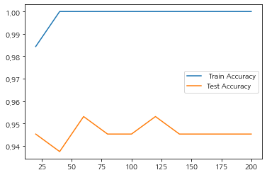

```python
# 모델 정확도 그래프 확인
plt.plot(para_hidden, train_accuracy, linestyle='-', label = ' Train Accuracy')
plt.plot(para_hidden, test_accuracy, linestyle='-', label = 'Test Accuracy')
plt.legend()
```

- 은닉층 구조가 복잡할수록 train data에 대한 모델 정확도는 상승한다. 40부터는 과대적합(1.000)되었다.
- test data에 대한 모델 정확도는 변동이 있지만, 값의 차이가 0.01 내외라서 큰 차이를 보이지 않았다.

#### Activation: 활성화 함수 변경

```python
#train 및 test 정확도 결과 저장용
train_accuracy = []; test_accuracy = []
#activation 변경
para_function = ['logistic','tanh','relu']

for v_function in para_function:
    nn = MLPClassifier(activation=v_function,hidden_layer_sizes = (80,80),random_state=1234)
    nn.fit(df_scaled_train_x,df_train_y)
    train_accuracy.append(nn.score(df_scaled_train_x,df_train_y))
    test_accuracy.append(nn.score(df_scaled_test_x,df_test_y))

#데이터 테이블로 저장
df_accuracy_function = pd.DataFrame()
df_accuracy_function['ActivationFunction'] = para_function
df_accuracy_function['TrainAccuracy'] = train_accuracy
df_accuracy_function['TestAccuracy'] = test_accuracy
```

```python
#Activation Function 별 정확도 테이블
df_accuracy_function.round(3)
```

|  | ActivationFunction | TrainAccuracy | TestAccuracy |
| --- | --- | --- | --- |
| 0 | logistic | 0.995 | 0.938 |
| 1 | tanh | 1.000 | 0.953 |
| 2 | relu | 1.000 | 0.945 |

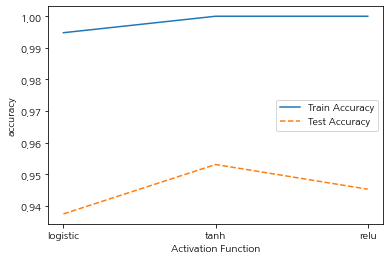

```python
#Activation Function 별 정확도 그래프 확인
plt.plot(para_function,train_accuracy,linestyle = '-',label = 'Train Accuracy')
plt.plot(para_function,test_accuracy,linestyle='--',label = 'Test Accuracy')
plt.ylabel('accuracy');plt.xlabel('Activation Function')
plt.legend()
```

- tanh 모델이 가장 높은 정확도를 보였다.

#### Solver: 가중치 최적화 변경

```python
#184
train_accuracy=[];test_accuracy=[]
para_solver=['lbfgs','sgd','adam']
for v_solver in para_solver:
    nn= MLPClassifier(solver=v_solver,activation='relu',hidden_layer_sizes=(80,80),random_state=1234)
    nn.fit(df_scaled_train_x,df_train_y)
    train_accuracy.append(nn.score(df_scaled_train_x,df_train_y))
    test_accuracy.append(nn.score(df_scaled_test_x,df_test_y))
# 데이터 테이블로 저장
df_accuracy_solver=pd.DataFrame()
df_accuracy_solver["Solver"]=para_solver
df_accuracy_solver["TrainAccuracy"]=train_accuracy
df_accuracy_solver["TestAccuracy"]=test_accuracy
```

```python
df_accuracy_solver.round(3)
```

|  | Solver | TrainAccuracy | TestAccuracy |
| --- | --- | --- | --- |
| 0 | lbfgs | 1.000 | 0.945 |
| 1 | sgd | 0.964 | 0.883 |
| 2 | adam | 1.000 | 0.945 |

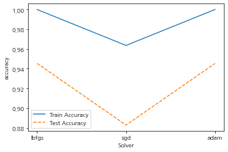

```python
#정확도 그래프 표현
plt.plot(para_solver,train_accuracy,linestyle="-",label="Train Accuracy")
plt.plot(para_solver,test_accuracy,linestyle="--",label="Test Accuracy")
plt.ylabel("accuracy");plt.xlabel("Solver")
plt.legend()
```

- lbfgs, adam 모델 둘다 동일한 정확도를 보이고 있다.

#### Mini Batch 변경

```python
# train 및 test 정확도 결과 저장용
train_accuracy = []
test_accuracy = []

# Mini Batch 변경
para_batch = [20 * batch for batch in range(1, 10)]

for v_batch in para_batch:
    nn = MLPClassifier(batch_size=v_batch, solver="adam", activation="relu", hidden_layer_sizes = (80, 80), random_state=1234)
    nn.fit(df_scaled_train_x, df_train_y)
    train_accuracy.append(nn.score(df_scaled_train_x, df_train_y))
    test_accuracy.append(nn.score(df_scaled_test_x, df_test_y))

# 데이터 테이블로 저장
df_accuracy_batch = pd.DataFrame()
df_accuracy_batch["Mini Batch"] = para_batch
df_accuracy_batch["TrainAccuracy"] = train_accuracy
df_accuracy_batch["TestAccuracy"] = test_accuracy
```

```python
# Mini Batch Size 별 정확도 테이블
df_accuracy_batch.round(3)
```

|  | Mini Batch | TrainAccuracy | TestAccuracy |
| --- | --- | --- | --- |
| 0 | 20 | 1.0 | 0.945 |
| 1 | 40 | 1.0 | 0.938 |
| 2 | 60 | 1.0 | 0.938 |
| 3 | 80 | 1.0 | 0.945 |
| 4 | 100 | 1.0 | 0.938 |
| 5 | 120 | 1.0 | 0.938 |
| 6 | 140 | 1.0 | 0.938 |
| 7 | 160 | 1.0 | 0.945 |
| 8 | 180 | 1.0 | 0.938 |

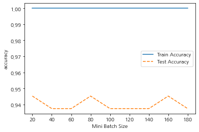

```python
# 정확도 그래프 표현
plt.plot(para_batch,train_accuracy,linestyle='-',label = 'Train Accuracy')
plt.plot(para_batch,test_accuracy,linestyle='--',label = 'Test Accuracy')
plt.ylabel('accuracy');plt.xlabel('Mini Batch Size')
plt.legend()
```

- train data에는 과적합, test data는 미니 배치 크기에 따라 차이가 있다. 하지만 0.01 내외로 큰 차이는 아니다.

### 결론

#### 최종 모델

```python
nn_final = MLPClassifier(hidden_layer_sizes = (80,80), activation = "tanh", solver = "adam",
                         batch_size = 80, random_state =1234)
nn_final.fit(df_scaled_train_x, df_train_y)
y_pred = nn_final.predict(df_scaled_test_x)
#train 데이터 셋 정확도
print("Accuracy on train set: {:.3f}".format(nn_final.score(df_scaled_train_x, df_train_y)))
#test 데이터 셋 정확도
print("Accuracy on test set: {:.3f}\n".format(nn_final.score(df_scaled_test_x, df_test_y)))
#confusion matrix
print("Confusion matrix:\n{}".format(confusion_matrix(df_test_y,y_pred)))
#목표변수의 빈도 불균형 : f1 score로 모델평가
print(classification_report(df_test_y, y_pred, digits = 3))
```

```
Accuracy on train set: 1.000
Accuracy on test set: 0.953

Confusion matrix:
[[91  6]
 [ 0 31]]
              precision    recall  f1-score   support

           0      1.000     0.938     0.968        97
           1      0.838     1.000     0.912        31

    accuracy                          0.953       128
   macro avg      0.919     0.969     0.940       128
weighted avg      0.961     0.953     0.954       128
```

- test data기준 정분류율은 95.3%이다.
- 1 기준 f1 score는 91.2%이다. precision은 83.8%로, 100%인 recall에 비해 많이 낮게 나왔다.

## KNN

```python
# 데이터 처리
import pandas as pd
# 데이터 시각화
import matplotlib
import matplotlib.pyplot as plt

# 데이터 스케일링
from sklearn.preprocessing import StandardScaler
# 데이터 분할: train, test
from sklearn.model_selection import train_test_split
# 분류 SVM
from sklearn.neighbors import KNeighborsClassifier
# 최적모델 파라미터 탐색
from sklearn.model_selection import GridSearchCV

import seaborn as sns

# 분류모델 평가 함수
from sklearn.metrics import accuracy_score, f1_score
from sklearn.metrics import confusion_matrix, classification_report
```

### 데이터 구성하기

```python
df_raw = pd.read_csv("../빅데이터 기초/Data/유방암.csv",encoding='euc-kr')
df_raw.head()
```

|  | diagnosis | mean_radius | mean_texture | mean_perimeter | mean_area | mean_smoothness | mean_compactness | mean_concavity | mean_concave_points | mean_symmetry | ... | worst_radius | worst_texture | worst_perimeter | worst_area | worst_smoothness | worst_compactness | worst_concavity | worst_concave_points | worst_symmetry | worst_fractal_dimension |
| --- | --- | --- | --- | --- | --- | --- | --- | --- | --- | --- | --- | --- | --- | --- | --- | --- | --- | --- | --- | --- | --- |
| 0 | 음성 | 15.12 | 16.68 | 98.78 | 716.6 | 0.08876 | 0.09588 | 0.07550 | 0.04079 | 0.1594 | ... | 17.77 | 20.24 | 117.70 | 989.5 | 0.14910 | 0.3331 | 0.3327 | 0.12520 | 0.3415 | 0.09740 |
| 1 | 양성 | 10.80 | 9.71 | 68.77 | 357.6 | 0.09594 | 0.05736 | 0.02531 | 0.01698 | 0.1381 | ... | 11.60 | 12.02 | 73.66 | 414.0 | 0.14360 | 0.1257 | 0.1047 | 0.04603 | 0.2090 | 0.07699 |
| 2 | 음성 | 18.31 | 18.58 | 118.60 | 1041.0 | 0.08588 | 0.08468 | 0.08169 | 0.05814 | 0.1621 | ... | 21.31 | 26.36 | 139.20 | 1410.0 | 0.12340 | 0.2445 | 0.3538 | 0.15710 | 0.3206 | 0.06938 |
| 3 | 양성 | 14.92 | 14.93 | 96.45 | 686.9 | 0.08098 | 0.08549 | 0.05539 | 0.03221 | 0.1687 | ... | 17.18 | 18.22 | 112.00 | 906.6 | 0.10650 | 0.2791 | 0.3151 | 0.11470 | 0.2688 | 0.08273 |
| 4 | 양성 | 12.89 | 13.12 | 81.89 | 515.9 | 0.06955 | 0.03729 | 0.02260 | 0.01171 | 0.1337 | ... | 13.62 | 15.54 | 87.40 | 577.0 | 0.09616 | 0.1147 | 0.1186 | 0.05366 | 0.2309 | 0.06915 |

5 rows × 31 columns

```python
# 데이터 분리 (Y, Xs) -> 설명변수를 이용한 주성분 분석
df_raw_x = df_raw.drop("diagnosis", axis = 1)
df_raw_y = df_raw["diagnosis"]
df_raw_y.head()
```

```
0    음성
1    양성
2    음성
3    양성
4    양성
Name: diagnosis, dtype: object
```

```python
df_raw_y.replace("양성", 1, inplace=True)
df_raw_y.replace("음성", 0, inplace=True)
```

양성을 1, 음성을 0으로 변환하였다.

```python
df_raw_y.head()
```

```
0    0
1    1
2    0
3    1
4    1
Name: diagnosis, dtype: int64
```

```python
df_raw['diagnosis'].value_counts() # oversampling 안해도 될 것 같다.
```

```
0    212
1    108
Name: diagnosis, dtype: int64
```

```python
# get dummies : 데이터의 문자형 변수에 대한 더미변수 생성
df_raw_dummy = pd.get_dummies(df_raw)
# 더미변수 생성된 데이터의 상위 5개 row 확인
df_raw_dummy.head()
```

|  | diagnosis | mean_radius | mean_texture | mean_perimeter | mean_area | mean_smoothness | mean_compactness | mean_concavity | mean_concave_points | mean_symmetry | ... | worst_radius | worst_texture | worst_perimeter | worst_area | worst_smoothness | worst_compactness | worst_concavity | worst_concave_points | worst_symmetry | worst_fractal_dimension |
| --- | --- | --- | --- | --- | --- | --- | --- | --- | --- | --- | --- | --- | --- | --- | --- | --- | --- | --- | --- | --- | --- |
| 0 | 0 | 15.12 | 16.68 | 98.78 | 716.6 | 0.08876 | 0.09588 | 0.07550 | 0.04079 | 0.1594 | ... | 17.77 | 20.24 | 117.70 | 989.5 | 0.14910 | 0.3331 | 0.3327 | 0.12520 | 0.3415 | 0.09740 |
| 1 | 1 | 10.80 | 9.71 | 68.77 | 357.6 | 0.09594 | 0.05736 | 0.02531 | 0.01698 | 0.1381 | ... | 11.60 | 12.02 | 73.66 | 414.0 | 0.14360 | 0.1257 | 0.1047 | 0.04603 | 0.2090 | 0.07699 |
| 2 | 0 | 18.31 | 18.58 | 118.60 | 1041.0 | 0.08588 | 0.08468 | 0.08169 | 0.05814 | 0.1621 | ... | 21.31 | 26.36 | 139.20 | 1410.0 | 0.12340 | 0.2445 | 0.3538 | 0.15710 | 0.3206 | 0.06938 |
| 3 | 1 | 14.92 | 14.93 | 96.45 | 686.9 | 0.08098 | 0.08549 | 0.05539 | 0.03221 | 0.1687 | ... | 17.18 | 18.22 | 112.00 | 906.6 | 0.10650 | 0.2791 | 0.3151 | 0.11470 | 0.2688 | 0.08273 |
| 4 | 1 | 12.89 | 13.12 | 81.89 | 515.9 | 0.06955 | 0.03729 | 0.02260 | 0.01171 | 0.1337 | ... | 13.62 | 15.54 | 87.40 | 577.0 | 0.09616 | 0.1147 | 0.1186 | 0.05366 | 0.2309 | 0.06915 |

5 rows × 31 columns

```python
# 설명변수, 목표변수 데이터 구분
df_raw_x = df_raw_dummy.drop("diagnosis", axis = 1, inplace= False)
df_raw_y = df_raw_dummy["diagnosis"]

# 데이터 분할 train_test_split(X:설명변수, Y: 목표변수 , test_size = test 데이터 비율)
df_train_x, df_test_x, df_train_y, df_test_y = train_test_split(df_raw_x, df_raw_y, test_size= 0.4, random_state=1234)
print("분할 전 설명변수 데이터: ", df_raw_x.shape)
print("분할 후 설명변수 데이터: Train", df_train_x.shape, "Test", df_test_x.shape)
```

```
분할 전 설명변수 데이터:  (320, 30)
분할 후 설명변수 데이터: Train (192, 30) Test (128, 30)
```

### 모델 생성

```python
# KNN 모델 생성(default 설정)
knn_uncustomized = KNeighborsClassifier()
knn_uncustomized.fit(df_train_x, df_train_y)

# train/test 데이터 셋 정확도
print("Accuracy on training set: {:.3f}".format(knn_uncustomized.score(df_train_x, df_train_y)))
print("Accuracy on test set: {:.3f}".format(knn_uncustomized.score(df_test_x, df_test_y)))
```

```
Accuracy on training set: 0.932
Accuracy on test set: 0.914
```

- train data에 대한 정확도는 93.2%, test data에 대한 정확도는 91.4%이다. 성능이 유사한 편이다. 약간의 과소적합 경향이 있다.

#### 이웃 수 증가에 따른 정확도 변화

```python
#train 및 test 정확도 결과 저장용
train_accuracy = []
test_accuracy = []

# 최대 이웃 수: 3~30
para_n_neighbors = [i for i in range(3, 31)]

for v_n_neighbors in para_n_neighbors:
    knn = KNeighborsClassifier(n_neighbors=v_n_neighbors)
    knn.fit(df_train_x, df_train_y)
    train_accuracy.append(knn.score(df_train_x, df_train_y))
    test_accuracy.append(knn.score(df_test_x, df_test_y))

#데이터 테이블로 저장
df_accuracy_neighbors = pd.DataFrame()
df_accuracy_neighbors['Neighbors'] = para_n_neighbors
df_accuracy_neighbors['TrainAccuracy'] = train_accuracy
df_accuracy_neighbors['TestAccuracy'] = test_accuracy
```

```python
df_accuracy_neighbors.round(3)
```

|  | Neighbors | TrainAccuracy | TestAccuracy |
| --- | --- | --- | --- |
| 0 | 3 | 0.932 | 0.898 |
| 1 | 4 | 0.911 | 0.891 |
| 2 | 5 | 0.932 | 0.914 |
| 3 | 6 | 0.927 | 0.914 |
| 4 | 7 | 0.927 | 0.898 |
| 5 | 8 | 0.922 | 0.914 |
| 6 | 9 | 0.911 | 0.906 |
| 7 | 10 | 0.911 | 0.906 |
| 8 | 11 | 0.917 | 0.906 |
| 9 | 12 | 0.917 | 0.906 |
| 10 | 13 | 0.911 | 0.914 |
| 11 | 14 | 0.917 | 0.906 |
| 12 | 15 | 0.917 | 0.906 |
| 13 | 16 | 0.911 | 0.906 |
| 14 | 17 | 0.901 | 0.906 |
| 15 | 18 | 0.906 | 0.898 |
| 16 | 19 | 0.896 | 0.906 |
| 17 | 20 | 0.891 | 0.906 |
| 18 | 21 | 0.896 | 0.898 |
| 19 | 22 | 0.901 | 0.898 |
| 20 | 23 | 0.885 | 0.891 |
| 21 | 24 | 0.885 | 0.898 |
| 22 | 25 | 0.885 | 0.898 |
| 23 | 26 | 0.891 | 0.898 |
| 24 | 27 | 0.885 | 0.898 |
| 25 | 28 | 0.885 | 0.898 |
| 26 | 29 | 0.885 | 0.906 |
| 27 | 30 | 0.885 | 0.906 |

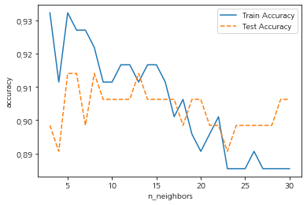

```python
#모델 정확도 그래프 확인
plt.plot(para_n_neighbors,train_accuracy,linestyle='-',label = 'Train Accuracy')
plt.plot(para_n_neighbors,test_accuracy,linestyle='--',label = 'Test Accuracy')
plt.ylabel('accuracy');plt.xlabel('n_neighbors')
plt.legend()
```

- 군집의 수가 증가할수록 train data에 대한 정확도는 감소, test data에 대한 정확도는 뚜렷한 경향 없이 계속 변하였다.

#### 가중치별 이웃 수 증가에 따른 정확도 변화

```python
# train 및 test 정확도 결과 저장용
train_accuracy = []
test_accuracy = []

# 이웃 수
para_n_neighbors = [i for i in range(1, 11)] * 2

# 가중치(uniform, distance)
para_weights = (["uniform"]) * 10 + (["distance"] * 10)

# zip(list1, list2, ...)을 사용하면 list1과 list2의 인덱스별 값을 하나씩 가져옴
# 1번 loop: n_neighbors = para_n_neighbors[0], weights = para_weights[0]
# 2번 loop: n_neighbors = para_n_neighbors[1], weights = para_weights[1]
for (v_n_neighbors, v_weights) in zip(para_n_neighbors, para_weights):
    knn = KNeighborsClassifier(n_neighbors=v_n_neighbors, weights=v_weights)
    knn.fit(df_train_x, df_train_y)
    train_accuracy.append(knn.score(df_train_x, df_train_y))
    test_accuracy.append(knn.score(df_test_x, df_test_y))

# 데이터 테이블로 저장
df_accuracy_weights = pd.DataFrame()
df_accuracy_weights["Neighbors"] = para_n_neighbors
df_accuracy_weights["Weights"] = para_weights
df_accuracy_weights["TrainAccuracy"] = train_accuracy
df_accuracy_weights["TestAccuracy"] = test_accuracy
```

```python
df_accuracy_weights.round(3)
```

|  | Neighbors | Weights | TrainAccuracy | TestAccuracy |
| --- | --- | --- | --- | --- |
| 0 | 1 | uniform | 1.000 | 0.898 |
| 1 | 2 | uniform | 0.938 | 0.914 |
| 2 | 3 | uniform | 0.932 | 0.898 |
| 3 | 4 | uniform | 0.911 | 0.891 |
| 4 | 5 | uniform | 0.932 | 0.914 |
| 5 | 6 | uniform | 0.927 | 0.914 |
| 6 | 7 | uniform | 0.927 | 0.898 |
| 7 | 8 | uniform | 0.922 | 0.914 |
| 8 | 9 | uniform | 0.911 | 0.906 |
| 9 | 10 | uniform | 0.911 | 0.906 |
| 10 | 1 | distance | 1.000 | 0.898 |
| 11 | 2 | distance | 1.000 | 0.898 |
| 12 | 3 | distance | 1.000 | 0.898 |
| 13 | 4 | distance | 1.000 | 0.898 |
| 14 | 5 | distance | 1.000 | 0.914 |
| 15 | 6 | distance | 1.000 | 0.930 |
| 16 | 7 | distance | 1.000 | 0.891 |
| 17 | 8 | distance | 1.000 | 0.906 |
| 18 | 9 | distance | 1.000 | 0.914 |
| 19 | 10 | distance | 1.000 | 0.930 |

```python
# 그림을 그리기 위해 데이터의 형태롤 변환
df_accuracy_weights_pivot = df_accuracy_weights.pivot(index="Neighbors", columns="Weights", values=["TrainAccuracy", "TestAccuracy"])
df_accuracy_weights_pivot
```

| Weights Neighbors | TrainAccuracy distance | TrainAccuracy uniform | TestAccuracy distance | TestAccuracy uniform |
| --- | --- | --- | --- | --- |
| 1 | 1.0 | 1.000000 | 0.898438 | 0.898438 |
| 2 | 1.0 | 0.937500 | 0.898438 | 0.914062 |
| 3 | 1.0 | 0.932292 | 0.898438 | 0.898438 |
| 4 | 1.0 | 0.911458 | 0.898438 | 0.890625 |
| 5 | 1.0 | 0.932292 | 0.914062 | 0.914062 |
| 6 | 1.0 | 0.927083 | 0.929688 | 0.914062 |
| 7 | 1.0 | 0.927083 | 0.890625 | 0.898438 |
| 8 | 1.0 | 0.921875 | 0.906250 | 0.914062 |
| 9 | 1.0 | 0.911458 | 0.914062 | 0.906250 |
| 10 | 1.0 | 0.911458 | 0.929688 | 0.906250 |

```python
# pivot을 이용할 경우, columns와 values이 2개의 level로 이루어지므로 하나의 level로 변환
level0 = df_accuracy_weights_pivot.columns.get_level_values(0)
level1 = df_accuracy_weights_pivot.columns.get_level_values(1)
df_accuracy_weights_pivot.columns = level0 + "_" + level1
df_accuracy_weights_pivot.head()
```

| Neighbors | TrainAccuracy_distance | TrainAccuracy_uniform | TestAccuracy_distance | TestAccuracy_uniform |
| --- | --- | --- | --- | --- |
| 1 | 1.0 | 1.000000 | 0.898438 | 0.898438 |
| 2 | 1.0 | 0.937500 | 0.898438 | 0.914062 |
| 3 | 1.0 | 0.932292 | 0.898438 | 0.898438 |
| 4 | 1.0 | 0.911458 | 0.898438 | 0.890625 |
| 5 | 1.0 | 0.932292 | 0.914062 | 0.914062 |

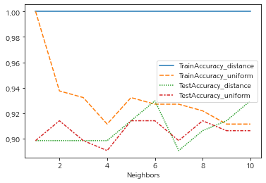

```python
sns.lineplot(data=df_accuracy_weights_pivot)
```

- distance일 경우, train data에 대해 과대적합이 일어났다.

#### 거리 계산 방법별 이웃 수 증가에 따른 정확도 변화

```python
# train 및 test 정확도 결과 저장용
train_accuracy  = []
test_accuracy = []

# 이웃 수
para_n_neighbors = [i for i in range(1,11)] * 3
# 거리 계산 방법
para_metric = ["minkowski"] * 10 + ['euclidean'] * 10 + ['manhattan'] * 10

for (v_n_neighbors, v_metric) in zip(para_n_neighbors, para_metric):
    knn = KNeighborsClassifier(n_neighbors=v_n_neighbors, metric=v_metric, weights="uniform")
    knn.fit(df_train_x, df_train_y)
    train_accuracy.append(knn.score(df_train_x, df_train_y))
    test_accuracy.append(knn.score(df_test_x, df_test_y))

# 데이터 테이블로 저장
df_accuracy_metric = pd.DataFrame()
df_accuracy_metric["Neighbors"] = para_n_neighbors
df_accuracy_metric["Metric"] = para_metric
df_accuracy_metric["TrainAccuracy"] = train_accuracy
df_accuracy_metric["TestAccuracy"] = test_accuracy
df_accuracy_metric.round(3)
```

|  | Neighbors | Metric | TrainAccuracy | TestAccuracy |
| --- | --- | --- | --- | --- |
| 0 | 1 | minkowski | 1.000 | 0.898 |
| 1 | 2 | minkowski | 0.938 | 0.914 |
| 2 | 3 | minkowski | 0.932 | 0.898 |
| 3 | 4 | minkowski | 0.911 | 0.891 |
| 4 | 5 | minkowski | 0.932 | 0.914 |
| 5 | 6 | minkowski | 0.927 | 0.914 |
| 6 | 7 | minkowski | 0.927 | 0.898 |
| 7 | 8 | minkowski | 0.922 | 0.914 |
| 8 | 9 | minkowski | 0.911 | 0.906 |
| 9 | 10 | minkowski | 0.911 | 0.906 |
| 10 | 1 | euclidean | 1.000 | 0.898 |
| 11 | 2 | euclidean | 0.938 | 0.914 |
| 12 | 3 | euclidean | 0.932 | 0.898 |
| 13 | 4 | euclidean | 0.911 | 0.891 |
| 14 | 5 | euclidean | 0.932 | 0.914 |
| 15 | 6 | euclidean | 0.927 | 0.914 |
| 16 | 7 | euclidean | 0.927 | 0.898 |
| 17 | 8 | euclidean | 0.922 | 0.914 |
| 18 | 9 | euclidean | 0.911 | 0.906 |
| 19 | 10 | euclidean | 0.911 | 0.906 |
| 20 | 1 | manhattan | 1.000 | 0.906 |
| 21 | 2 | manhattan | 0.953 | 0.930 |
| 22 | 3 | manhattan | 0.932 | 0.898 |
| 23 | 4 | manhattan | 0.922 | 0.914 |
| 24 | 5 | manhattan | 0.943 | 0.938 |
| 25 | 6 | manhattan | 0.927 | 0.922 |
| 26 | 7 | manhattan | 0.917 | 0.922 |
| 27 | 8 | manhattan | 0.927 | 0.914 |
| 28 | 9 | manhattan | 0.917 | 0.914 |
| 29 | 10 | manhattan | 0.911 | 0.930 |

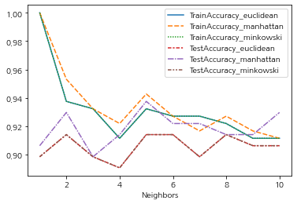

```python
# 정확도를 그래프로 그림
df_accuracy_metric_pivot =df_accuracy_metric.pivot(index = "Neighbors" ,columns = "Metric", values = ["TrainAccuracy", "TestAccuracy"])

level0=df_accuracy_metric_pivot.columns.get_level_values(0)
level1=df_accuracy_metric_pivot.columns.get_level_values(1)
df_accuracy_metric_pivot.columns=level0+"_"+level1
sns.lineplot(data = df_accuracy_metric_pivot)
```

- minkowski와 euclidean은 정확도의 차이가 없다.
- manhattan의 정확도가 가장 높다.

### 결론

```python
# 최종모델
knn_model = KNeighborsClassifier(n_neighbors=5, weights="uniform", metric = "manhattan")
knn_model.fit(df_train_x, df_train_y)
y_pred =knn_model.predict(df_test_x)

print("train data accuracy:{0:.3f}".format(knn_model.score(df_train_x, df_train_y)))
print("test data accuracy:{0:.3f}".format(knn_model.score(df_test_x, df_test_y)))
print("Confusion matrix: \n{}".format(confusion_matrix(df_test_y, y_pred)))
print(classification_report(df_test_y, y_pred, digits=3))
```

```
train data accuracy:0.943
test data accuracy:0.938
Confusion matrix:
[[90  7]
 [ 1 30]]
              precision    recall  f1-score   support

           0      0.989     0.928     0.957        97
           1      0.811     0.968     0.882        31

    accuracy                          0.938       128
   macro avg      0.900     0.948     0.920       128
weighted avg      0.946     0.938     0.939       128
```

- test 데이터 기준 정확도는 93.8%가 나왔다.
- 1 기준 f1 score는 88.2%이다.
- precision은 81.1%이다. 1로 예측한 것 중에 실제 1인 것의 비율이 낮다. recall에 비해 많이 낮게 나왔다.
- recall은 96.8%로 높게 나왔다. 실제 1을 1로 예측한 것의 비율이 높다.